# Fantasy Premier League

## Fantasy Premier League Data Analysis:

### Tools to help your performance in FPL

#### By Adam Kaushik

**Introduction**

The goal of this tutorial is to use data to learn more about Premier League players' performances in FPL, to help people build their FPL teams. This would be extremely useful for any user, either in giving new insights to more knowledgeable users as to player performances to combine with their own pre-established knowledge of FPL or to help more novice users looking to rely more on the data.

Note: this tutorial assumes a basic grasp of python, pandas, and requests.

**Imports**

Below we just import some packages we'll be using to retrieve, interact with, and visualize data.

```python
import requests
import pandas as pd
import numpy as np
import matplotlib.pyplot as plt
import seaborn as sns
```

**Retrieval**

Here, we want to access the Fantasy Premier League API. This is a straightforward process.

```python
r = requests.get('https://fantasy.premierleague.com/api/bootstrap-static/')
# show key data subsets
r.json().keys()
```

```
dict_keys(['events', 'game_settings', 'phases', 'teams', 'total_players', 'elements', 'element_stats', 'element_types'])
```

**Data tidying**

We can see various tables here. We will just be using the 'elements' and 'element types'. You will see why we use these particular ones. The other tables have useful information, but not for what we're looking at here, specifically.

At this point, we aren't gathering more data. What we're doing is taking the data we just retrieved and manipulating it. There are certain parts of the data we care about, and some we don't. This section is about putting what we care about in one place for easy access.

```python
players = pd.DataFrame(r.json()['elements'])
players
```

|  | chance_of_playing_next_round | chance_of_playing_this_round | code | cost_change_event | cost_change_event_fall | cost_change_start | cost_change_start_fall | dreamteam_count | element_type | ep_next | ... | threat_rank | threat_rank_type | ict_index_rank | ict_index_rank_type | corners_and_indirect_freekicks_order | corners_and_indirect_freekicks_text | direct_freekicks_order | direct_freekicks_text | penalties_order | penalties_text |
| --- | --- | --- | --- | --- | --- | --- | --- | --- | --- | --- | --- | --- | --- | --- | --- | --- | --- | --- | --- | --- | --- |
| 0 | 0.0 | 0.0 | 37605 | 0 | 0 | -3 | 3 | 0 | 3 | 0.0 | ... | 703 | 288 | 703 | 288 | NaN |  | NaN |  | NaN |  |
| 1 | 0.0 | 0.0 | 39476 | 0 | 0 | -2 | 2 | 0 | 2 | 0.0 | ... | 656 | 236 | 675 | 238 | NaN |  | NaN |  | NaN |  |
| 2 | 75.0 | 75.0 | 41270 | 0 | 0 | -1 | 1 | 0 | 2 | 0.5 | ... | 221 | 60 | 298 | 100 | NaN |  | 4.0 |  | NaN |  |
| 3 | 100.0 | 100.0 | 54694 | 0 | 0 | -7 | 7 | 3 | 3 | 4.1 | ... | 34 | 18 | 51 | 30 | NaN |  | NaN |  | 1.0 |  |
| 4 | 100.0 | 100.0 | 58822 | 0 | 0 | -4 | 4 | 0 | 2 | 0.5 | ... | 319 | 106 | 345 | 123 | NaN |  | 5.0 |  | NaN |  |
| ... | ... | ... | ... | ... | ... | ... | ... | ... | ... | ... | ... | ... | ... | ... | ... | ... | ... | ... | ... | ... | ... |
| 698 | NaN | NaN | 448487 | 0 | 0 | 0 | 0 | 0 | 1 | 0.0 | ... | 505 | 32 | 556 | 61 | NaN |  | NaN |  | NaN |  |
| 699 | 0.0 | 0.0 | 209353 | 0 | 0 | -1 | 1 | 0 | 4 | 0.0 | ... | 427 | 68 | 502 | 69 | NaN |  | NaN |  | NaN |  |
| 700 | NaN | NaN | 465551 | 0 | 0 | -1 | 1 | 0 | 2 | 0.0 | ... | 469 | 181 | 523 | 193 | NaN |  | NaN |  | NaN |  |
| 701 | 100.0 | 100.0 | 73314 | 0 | 0 | -2 | 2 | 0 | 4 | 2.4 | ... | 168 | 45 | 291 | 43 | NaN |  | NaN |  | NaN |  |
| 702 | NaN | NaN | 490721 | 0 | 0 | 0 | 0 | 0 | 2 | 0.0 | ... | 515 | 206 | 566 | 217 | NaN |  | NaN |  | NaN |  |

703 rows × 67 columns

```python
players.columns
```

```
Index(['chance_of_playing_next_round', 'chance_of_playing_this_round', 'code',
       'cost_change_event', 'cost_change_event_fall', 'cost_change_start',
       'cost_change_start_fall', 'dreamteam_count', 'element_type', 'ep_next',
       'ep_this', 'event_points', 'first_name', 'form', 'id', 'in_dreamteam',
       'news', 'news_added', 'now_cost', 'photo', 'points_per_game',
       'second_name', 'selected_by_percent', 'special', 'squad_number',
       'status', 'team', 'team_code', 'total_points', 'transfers_in',
       'transfers_in_event', 'transfers_out', 'transfers_out_event',
       'value_form', 'value_season', 'web_name', 'minutes', 'goals_scored',
       'assists', 'clean_sheets', 'goals_conceded', 'own_goals',
       'penalties_saved', 'penalties_missed', 'yellow_cards', 'red_cards',
       'saves', 'bonus', 'bps', 'influence', 'creativity', 'threat',
       'ict_index', 'influence_rank', 'influence_rank_type', 'creativity_rank',
       'creativity_rank_type', 'threat_rank', 'threat_rank_type',
       'ict_index_rank', 'ict_index_rank_type',
       'corners_and_indirect_freekicks_order',
       'corners_and_indirect_freekicks_text', 'direct_freekicks_order',
       'direct_freekicks_text', 'penalties_order', 'penalties_text'],
      dtype='object')
```

We already see plenty of data about various players. But much of it is things we won't actually be using for this tutorial; let's trim that down. The 'total_points' column accounts for many things here, like red cards and goals, as they are what given points for a week are based on. Others still, like 'transfers_out', are meta values regarding what other FPL users are doing, not directly based on players' performance. Since we are focusing on player performance alone, the columns we select are the following:

```python
players = players[['second_name','element_type','now_cost','minutes','total_points']]
players.head()
```

|  | second_name | element_type | now_cost | minutes | total_points |
| --- | --- | --- | --- | --- | --- |
| 0 | Özil | 3 | 67 | 0 | 0 |
| 1 | Papastathopoulos | 2 | 48 | 0 | 0 |
| 2 | Luiz Moreira Marinho | 2 | 54 | 1396 | 41 |
| 3 | Aubameyang | 3 | 113 | 2162 | 126 |
| 4 | Soares | 2 | 46 | 744 | 28 |

So, what data do we have here? We know player names, their position in the game (for now again, just a code - the 'element_type'), their current price in FPL (needs to be changed; the values should be divided by ten, they are shown here as integers, which they shouldn't be), how many minutes they've played this season, and how many points they've earned this season.

Let's now unencode the positions and fix the costs to be as they are in the game. To do the former, we must get another dataframe, just as we got this one, from the element_types table.

```python
types = pd.DataFrame(r.json()['element_types'])
types.head()
```

|  | id | plural_name | plural_name_short | singular_name | singular_name_short | squad_select | squad_min_play | squad_max_play | ui_shirt_specific | sub_positions_locked | element_count |
| --- | --- | --- | --- | --- | --- | --- | --- | --- | --- | --- | --- |
| 0 | 1 | Goalkeepers | GKP | Goalkeeper | GKP | 2 | 1 | 1 | True | [12] | 80 |
| 1 | 2 | Defenders | DEF | Defender | DEF | 5 | 3 | 5 | False | [] | 244 |
| 2 | 3 | Midfielders | MID | Midfielder | MID | 5 | 2 | 5 | False | [] | 288 |
| 3 | 4 | Forwards | FWD | Forward | FWD | 3 | 1 | 3 | False | [] | 91 |

So, we can see here that the singular name is the actual position, and we can see the code (id column) they match in the players dataframe. So let's update the players object. Let's fix the costs too, while we're at it.

```python
players['position'] = players.element_type.map(types.set_index('id').singular_name)
players = players.drop('element_type', axis=1)
players['cost'] = players['now_cost']/10
players = players.drop('now_cost', axis=1)
players
```

|  | second_name | minutes | total_points | position | cost |
| --- | --- | --- | --- | --- | --- |
| 0 | Özil | 0 | 0 | Midfielder | 6.7 |
| 1 | Papastathopoulos | 0 | 0 | Defender | 4.8 |
| 2 | Luiz Moreira Marinho | 1396 | 41 | Defender | 5.4 |
| 3 | Aubameyang | 2162 | 126 | Midfielder | 11.3 |
| 4 | Soares | 744 | 28 | Defender | 4.6 |
| ... | ... | ... | ... | ... | ... |
| 698 | Söndergaard | 0 | 0 | Goalkeeper | 4.0 |
| 699 | Cutrone | 23 | 2 | Forward | 5.9 |
| 700 | Lonwijk | 0 | 0 | Defender | 3.9 |
| 701 | Da Silva | 994 | 36 | Forward | 6.8 |
| 702 | Bueno | 0 | 0 | Defender | 4.0 |

703 rows × 5 columns

**Data Analysis**

We now have just the data we want on our players, and can use it to make decisions about our FPL teams. Let's start by getting more interesting value from the data. For starters, let's create a column for points relative for cost. We will call this column "value_by_cost", as it represent, well, the player's value in points relative to how expensive they are in the game.

```python
players['value_by_cost'] = players.total_points/players.cost
players
```

|  | second_name | minutes | total_points | position | cost | value_by_cost |
| --- | --- | --- | --- | --- | --- | --- |
| 0 | Özil | 0 | 0 | Midfielder | 6.7 | 0.000000 |
| 1 | Papastathopoulos | 0 | 0 | Defender | 4.8 | 0.000000 |
| 2 | Luiz Moreira Marinho | 1396 | 41 | Defender | 5.4 | 7.592593 |
| 3 | Aubameyang | 2162 | 126 | Midfielder | 11.3 | 11.150442 |
| 4 | Soares | 744 | 28 | Defender | 4.6 | 6.086957 |
| ... | ... | ... | ... | ... | ... | ... |
| 698 | Söndergaard | 0 | 0 | Goalkeeper | 4.0 | 0.000000 |
| 699 | Cutrone | 23 | 2 | Forward | 5.9 | 0.338983 |
| 700 | Lonwijk | 0 | 0 | Defender | 3.9 | 0.000000 |
| 701 | Da Silva | 994 | 36 | Forward | 6.8 | 5.294118 |
| 702 | Bueno | 0 | 0 | Defender | 4.0 | 0.000000 |

703 rows × 6 columns

This is already useful, but how about a "value_by_minute column"? Maybe some players have played less, meaning they have less minutes, yet are scoring high. And maybe you happen to know they're going to play more now, whether because of injuries or players leaving/coming to their team. This is a metric that, as described in the introduction, would be more useful to those paying close attention to all these factors, as using this without knowing that may be pointless (they may do well in points per minute, but if they don't play, that's not going to be useful to your fantasy team).

```python
players['value_by_minute'] = players.total_points/players.minutes
players
```

|  | second_name | minutes | total_points | position | cost | value_by_cost | value_by_minute |
| --- | --- | --- | --- | --- | --- | --- | --- |
| 0 | Özil | 0 | 0 | Midfielder | 6.7 | 0.000000 | NaN |
| 1 | Papastathopoulos | 0 | 0 | Defender | 4.8 | 0.000000 | NaN |
| 2 | Luiz Moreira Marinho | 1396 | 41 | Defender | 5.4 | 7.592593 | 0.029370 |
| 3 | Aubameyang | 2162 | 126 | Midfielder | 11.3 | 11.150442 | 0.058279 |
| 4 | Soares | 744 | 28 | Defender | 4.6 | 6.086957 | 0.037634 |
| ... | ... | ... | ... | ... | ... | ... | ... |
| 698 | Söndergaard | 0 | 0 | Goalkeeper | 4.0 | 0.000000 | NaN |
| 699 | Cutrone | 23 | 2 | Forward | 5.9 | 0.338983 | 0.086957 |
| 700 | Lonwijk | 0 | 0 | Defender | 3.9 | 0.000000 | NaN |
| 701 | Da Silva | 994 | 36 | Forward | 6.8 | 5.294118 | 0.036217 |
| 702 | Bueno | 0 | 0 | Defender | 4.0 | 0.000000 | NaN |

703 rows × 7 columns

We immediately notice many NaN's appearing, due to players who haven't had a single minute of game time this season. Given that by all metrics but cost these players have no data (0 minutes, 0 points, 0 value by either metric), let's drop them. Maybe you have some intuition that they will get a chance soon, but the data doesn't tell us anything about their potential value to your fantasy team regardless, as they have 0 points from 0 minutes. So, while they are not exactly examples of missing data, they are still something to be trimmed from our dataframe.

```python
players = players.dropna()
players
```

|  | second_name | minutes | total_points | position | cost | value_by_cost | value_by_minute |
| --- | --- | --- | --- | --- | --- | --- | --- |
| 2 | Luiz Moreira Marinho | 1396 | 41 | Defender | 5.4 | 7.592593 | 0.029370 |
| 3 | Aubameyang | 2162 | 126 | Midfielder | 11.3 | 11.150442 | 0.058279 |
| 4 | Soares | 744 | 28 | Defender | 4.6 | 6.086957 | 0.037634 |
| 5 | Lacazette | 1905 | 128 | Forward | 8.4 | 15.238095 | 0.067192 |
| 6 | Mustafi | 45 | 3 | Defender | 5.0 | 0.600000 | 0.066667 |
| ... | ... | ... | ... | ... | ... | ... | ... |
| 689 | Cabral Semedo | 2713 | 99 | Defender | 5.2 | 19.038462 | 0.036491 |
| 691 | Ait Nouri | 1228 | 52 | Defender | 5.0 | 10.400000 | 0.042345 |
| 692 | Otasowie | 185 | 9 | Midfielder | 4.5 | 2.000000 | 0.048649 |
| 699 | Cutrone | 23 | 2 | Forward | 5.9 | 0.338983 | 0.086957 |
| 701 | Da Silva | 994 | 36 | Forward | 6.8 | 5.294118 | 0.036217 |

513 rows × 7 columns

Okay, now we have some new metrics beyond just points to judge players on. Let's look at the top performers by that last metric, shall we?

```python
players.sort_values('value_by_minute', ascending=False)
```

|  | second_name | minutes | total_points | position | cost | value_by_cost | value_by_minute |
| --- | --- | --- | --- | --- | --- | --- | --- |
| 96 | Molumby | 1 | 1 | Midfielder | 4.5 | 0.222222 | 1.000000 |
| 663 | Ruddy | 1 | 1 | Goalkeeper | 4.3 | 0.232558 | 1.000000 |
| 454 | Shoretire | 1 | 1 | Midfielder | 4.4 | 0.227273 | 1.000000 |
| 643 | Pereira Gomes | 2 | 2 | Midfielder | 6.1 | 0.327869 | 1.000000 |
| 592 | Scarlett | 1 | 1 | Forward | 4.5 | 0.222222 | 1.000000 |
| ... | ... | ... | ... | ... | ... | ... | ... |
| 158 | Tomori | 45 | 0 | Defender | 4.7 | 0.000000 | 0.000000 |
| 556 | Tchaptchet | 12 | 0 | Defender | 4.0 | 0.000000 | 0.000000 |
| 552 | Ramsay | 90 | -3 | Defender | 4.0 | -0.750000 | -0.033333 |
| 38 | Taylor | 15 | -1 | Defender | 4.2 | -0.238095 | -0.066667 |
| 558 | Jankewitz | 2 | -1 | Midfielder | 4.5 | -0.222222 | -0.500000 |

513 rows × 7 columns

There's a problem apparent straight away. On both ends of the dataframe, we see players with less than a single full game weighted strongly in either direction. Now, we can weight things more favorably to people with more minutes, but that would kind of defeat the purpose of using this metric in the first place. I propose that we get rid of players with under 270 minutes (that's three full-length games). If you've played less than that, we are considering you not being used enough to draw any meaningful conclusion from your data. That seems reasonable to me.

```python
players = players[players.minutes >= 270]
players.sort_values('value_by_minute', ascending=False)
```

|  | second_name | minutes | total_points | position | cost | value_by_cost | value_by_minute |
| --- | --- | --- | --- | --- | --- | --- | --- |
| 588 | Bale | 784 | 92 | Midfielder | 9.2 | 10.000000 | 0.117347 |
| 18 | Nketiah | 411 | 36 | Forward | 5.3 | 6.792453 | 0.087591 |
| 630 | Lingard | 1153 | 94 | Midfielder | 6.6 | 14.242424 | 0.081526 |
| 402 | Foden | 1462 | 119 | Midfielder | 6.1 | 19.508197 | 0.081395 |
| 430 | Borges Fernandes | 3011 | 240 | Midfielder | 11.4 | 21.052632 | 0.079708 |
| ... | ... | ... | ... | ... | ... | ... | ... |
| 128 | Peacock-Farrell | 360 | 3 | Goalkeeper | 4.0 | 0.750000 | 0.008333 |
| 515 | Jagielka | 517 | 4 | Defender | 3.9 | 1.025641 | 0.007737 |
| 111 | Bardsley | 273 | 2 | Defender | 4.4 | 0.454545 | 0.007326 |
| 596 | Gibbs | 810 | 5 | Defender | 4.3 | 1.162791 | 0.006173 |
| 268 | Odoi | 270 | 1 | Defender | 4.2 | 0.238095 | 0.003704 |

416 rows × 7 columns

Now, we have a table of data sortable by three useful metrics for performance (raw points, points based on cost, and points relative to time played). But this tool can be made more effective. Usually, when changing or creating your FPL team, you have specific gaps to fill. Maybe you're looking to replace a forward, for example. You can take this dataframe, sort by whatever metric you want, and look specifically at the top forwards. But why don't we make separate dataframes for different positions to make everyone's lives a little easier?

```python
# note that we reset the index: this will be useful for making plots later
# we also drop the position column, as that is going to be the same within each dataframe; that
# was why we split them, after all.
goalkeepers = players.loc[players.position == "Goalkeeper"]
goalkeepers = goalkeepers.reset_index().drop('index', axis=1).drop('position', axis=1)
defenders = players.loc[players.position == "Defender"]
defenders = defenders.reset_index().drop('index', axis=1).drop('position', axis=1)
midfielders = players.loc[players.position == "Midfielder"]
midfielders = midfielders.reset_index().drop('index', axis=1).drop('position', axis=1)
forwards = players.loc[players.position == "Forward"]
forwards = forwards.reset_index().drop('index', axis=1).drop('position', axis=1)
```

We now have four dataframes, each corresponding to a different FPL position, with different metrics to judge players on based on your needs and knowledge levels (Do you know someone will be playing more now? If they are high up when sorting by points per minute, it may be worth buying them. Don't know about that and just want the highest earner on average? Just sort by points. Need to do that but worrying about overall cost of your team? Sort by value by cost.) We have created a a set of tables we can use to help us decide what FPL players to buy for our team based on our needs and knowledge.

**Machine Learn- hey, this section is blank??**

Yep. There are some valuable insights machine learning can give us, generally speaking. But my goal with this tutorial was not to use the data to predict how players will perform in the future and give insight in that sense. In fact, the whole points per minute thing was a step away from this; a step towards having users, well, use their own knowledge and insight in conjunction with the data we have to make their decisions. I have no doubt that using machine learning, we would not have seen Lingard (3rd best in the last table I explicitly showed above) as a viable option; prior to his move to his current team in January, he had played no games. Even after first few games, he would not be doing well in either raw points or value by cost (as he only had a few games to rack up points despite getting many in the games he had). And factoring in value by minute wouldn't be helpful either in a machine learning approach; Nketiah, who is higher than Lingard in the same table, is not a viable pick, as his lack of minutes are down to not playing well (by actual coach/fan standards, not fantasy point standards) rather than mitigating circumstances like injuries or a transfer to a new team. The other metrics neglect these circumstances, and while this one accounts for them, it doesn't *just* do that, it accounts for people who aren't playing much due to a perceived lack of talent. So a human insight into these things is sort of essential, for me. Without it, we can't simultaneously see the detriments of Nketiah and the value of Lingard, and I can't think of a conceivable way to truly consider these things systematically. And rather than implement something trivial for the sake of saying 'hey look, we did machine learning here', I want everything in this tutorial to be something I truly believe is meaningful and useful to any FPL player. Not something that is likely to be misleading.

**Some visualization**

Okay, having gone through all that, why don't we actually look at the data in plot form, so we can more clearly see the meaning behind all the work we did? For starters, let's look at how one's points per minute looks when plotted against one's cost. We will do this four times, once for each position. These plots will show a player's performance based on the time they've played relative to their cost. This still relies on the intuition above to identify those whose points per minute may not be the best metric because their reasons for not playing too much are still relevant, however. I will be including a linear regression line in these plots, although I'm not sure the data suits one. At the end of the day, the higher and more leftward a player is, the better (as they will be the cheaper options who are performing well given the amount of time they've played), regardless of performance relative to some regression. And who knows, maybe the data will match that regression.

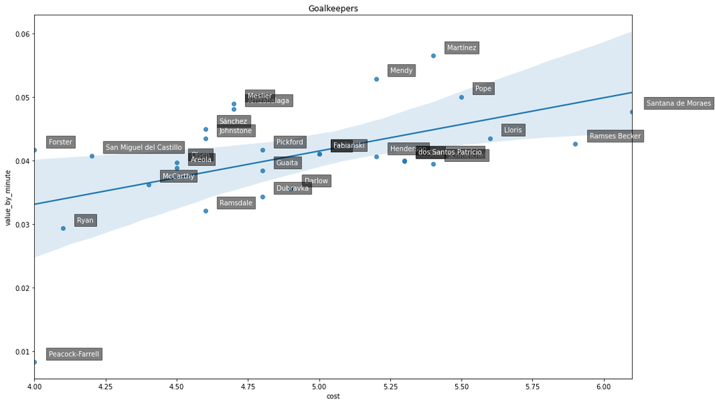

```python
plt.figure(figsize=(16,10))
sns.regplot(x='cost', y='value_by_minute', data=goalkeepers)

# code below adds labels so we can see which points on the plot correspond to what player
for i in range(goalkeepers.shape[0]):
    plt.text(x=goalkeepers.cost[i]+.05,y=goalkeepers.value_by_minute[i]+.001,s=goalkeepers.second_name[i],
          fontdict=dict(color='white',size=10),
          bbox=dict(facecolor='black',alpha=0.5))

plt.title('Goalkeepers')
plt.show()
```

We can see from this plot (I realize the names overlap quite a bit in some areas) that the likes of Martinez and Mendy, while somewhat expensive, are statistically performing well given their gametime this season. Meanwhile, Becker, Lloris, and de Moraes are expensive yet underperforming by this metric. Meanwhile, the likes of Meslier and Forster stand out as good cheaper options (provided we look at the tables and see they have decent amounts of gametime this season or know from external knowledge they're set to play more from this point onwards). If I wanted to change my goalkeeper for my FPL team, I'd be leaning towards Martinez or Meslier, based on my budget and actual knowledge of the Premier League.

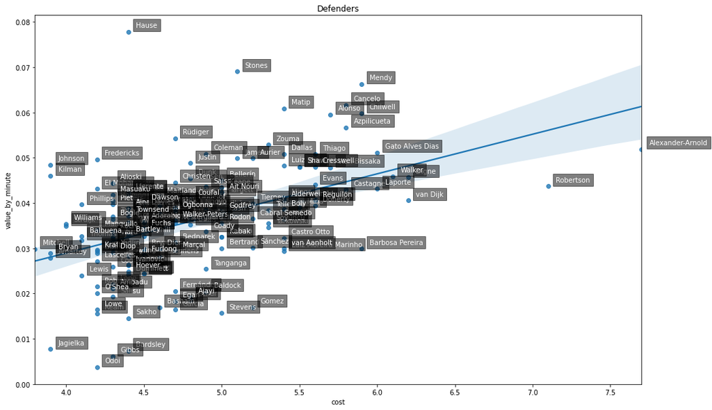

```python
plt.figure(figsize=(16,10))
sns.regplot(x='cost', y='value_by_minute', data=defenders)

for i in range(defenders.shape[0]):
    plt.text(x=defenders.cost[i]+.05,y=defenders.value_by_minute[i]+.001,s=defenders.second_name[i],
          fontdict=dict(color='white',size=10),
          bbox=dict(facecolor='black',alpha=0.5))

plt.title('Defenders')
plt.show()
```

Again, it's quite messy. For a more in-depth analysis, we may want to further scrub the dataframes (have a minumum value for raw points, perhaps) or just make the plot larger. For the sake of this, though, we can already draw conclusions. Alexander-Arnold is underperforming, as is Robertson, given their cost. Meanwhile, the likes of Mendy, Matip, Stones, and Hause stand out as good options depending on one's budget.

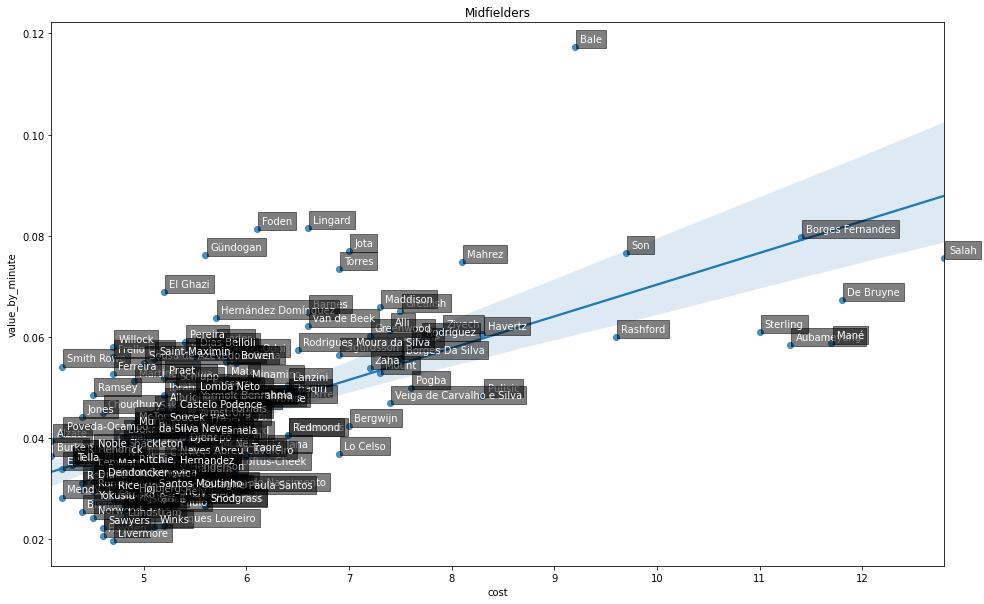

```python
plt.figure(figsize=(16,10))
sns.regplot(x='cost', y='value_by_minute', data=midfielders)

for i in range(midfielders.shape[0]):
    plt.text(x=midfielders.cost[i]+.05,y=midfielders.value_by_minute[i]+.001,s=midfielders.second_name[i],
          fontdict=dict(color='white',size=10),
          bbox=dict(facecolor='black',alpha=0.5))

plt.title('Midfielders')
plt.show()
```

The messiest plot of them all, due to the sheer number of FPL players counting as midfielders. Again, let's identify the standouts: Salah, De Bruyne, Mane, and Aubameyang seem like expensive options punching under their weight. Bale is an outlier, expensive but doing very well for his minutes, and the likes of Lingard, Foden, and Gundogan seem to be well-performing cheaper options.

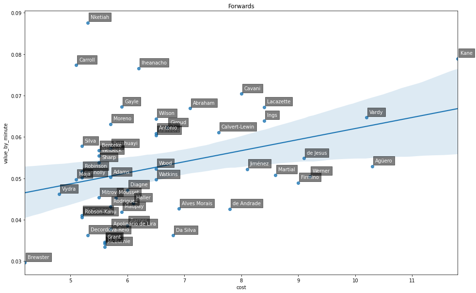

```python
plt.figure(figsize=(16,10))
sns.regplot(x='cost', y='value_by_minute', data=forwards)

for i in range(forwards.shape[0]):
    plt.text(x=forwards.cost[i]+.05,y=forwards.value_by_minute[i]+.001,s=forwards.second_name[i],
          fontdict=dict(color='white',size=10),
          bbox=dict(facecolor='black',alpha=0.5))

plt.title('Forwards')
plt.show()
```

This is the only plot where it seems the most expensive option is actually overperforming compared to the mean. Kane actually has an excellent value_by_minute despite his price. Nketiah, Carroll, and Iheanacho are the standout options. Again, I want to stress this as it is crucial to truly understanding this data, these are not necessarily the best pics for one's fantasy team. Maybe Nketiah only played 5 games this season, and he's injured for the remainder. I happen to know, specifically, that Nketiah and Carroll are not good picks (many players in their position outperforming them in real-world metrics, despite them doing well in regards to fantasy points), though Iheanacho is a great one at the moment. These plots rely on you, the reader, having some background knowledge in regards to things like that. For the sake of those less knowledgeable about such things but still enjoying playing FPL, let's draw up plots comparing raw points to cost. I'll let the data for those plots speak for themselves rather than point out the outliers in terms of over- and under-performers, though.

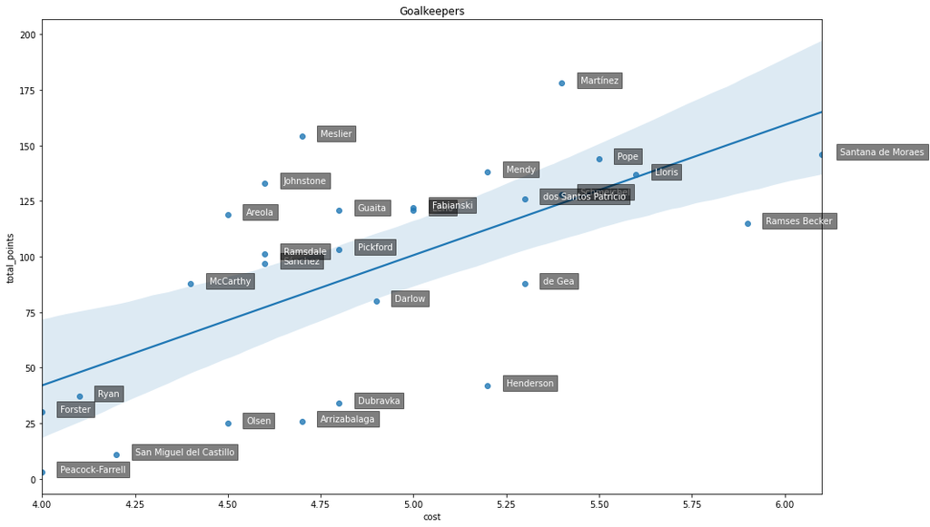

```python
plt.figure(figsize=(16,10))
sns.regplot(x='cost', y='total_points', data=goalkeepers)

for i in range(goalkeepers.shape[0]):
    plt.text(x=goalkeepers.cost[i]+.05,y=goalkeepers.total_points[i]+.001,s=goalkeepers.second_name[i],
          fontdict=dict(color='white',size=10),
          bbox=dict(facecolor='black',alpha=0.5))

plt.title('Goalkeepers')
plt.show()
```

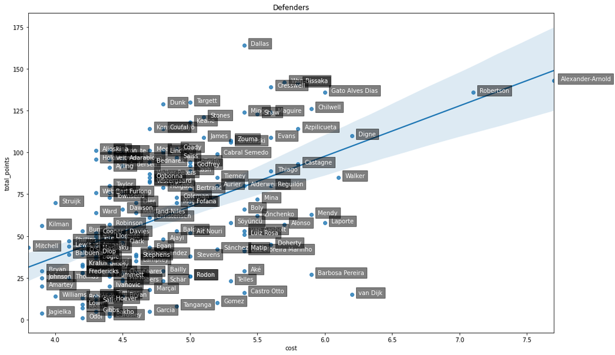

```python
plt.figure(figsize=(16,10))
sns.regplot(x='cost', y='total_points', data=defenders)

for i in range(defenders.shape[0]):
    plt.text(x=defenders.cost[i]+.05,y=defenders.total_points[i]+.001,s=defenders.second_name[i],
          fontdict=dict(color='white',size=10),
          bbox=dict(facecolor='black',alpha=0.5))

plt.title('Defenders')
plt.show()
```

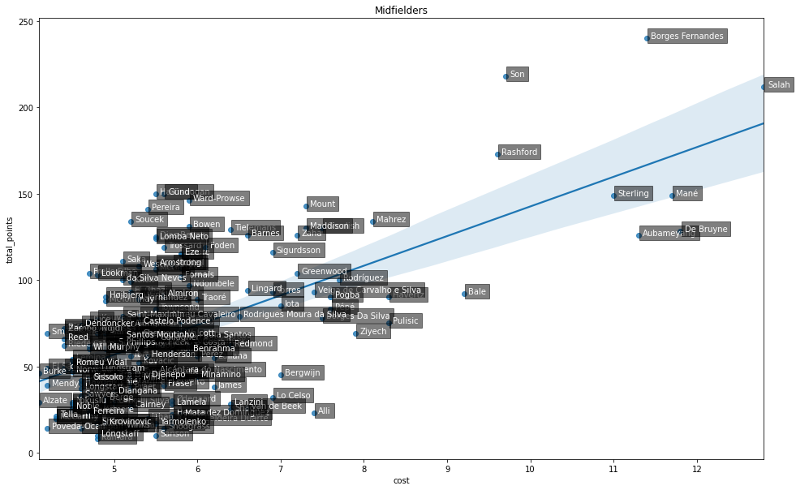

```python
plt.figure(figsize=(16,10))
sns.regplot(x='cost', y='total_points', data=midfielders)

for i in range(midfielders.shape[0]):
    plt.text(x=midfielders.cost[i]+.05,y=midfielders.total_points[i]+.001,s=midfielders.second_name[i],
          fontdict=dict(color='white',size=10),
          bbox=dict(facecolor='black',alpha=0.5))

plt.title('Midfielders')
plt.show()
```

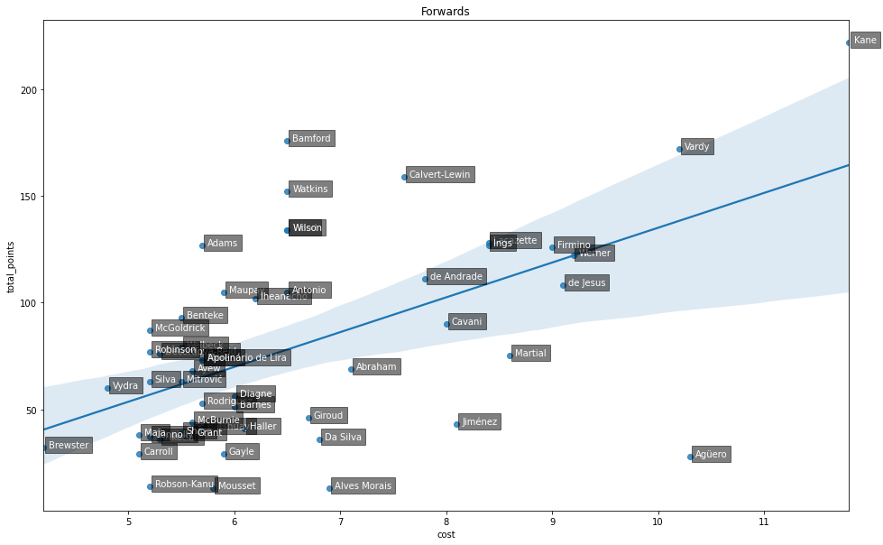

```python
plt.figure(figsize=(16,10))
sns.regplot(x='cost', y='total_points', data=forwards)

for i in range(forwards.shape[0]):
    plt.text(x=forwards.cost[i]+.05,y=forwards.total_points[i]+.001,s=forwards.second_name[i],
          fontdict=dict(color='white',size=10),
          bbox=dict(facecolor='black',alpha=0.5))

plt.title('Forwards')
plt.show()
```

**Miscellaneous**

Here are a few hypothetical scenarios we may find ourselves in, and how we can use what we've created to address them.

**Scenario 1**

Let's say you are disappointed with the returns one of your forwards is giving you. If you sell him, your remaining budget is 8.3. Let's see how you might go about picking his replacement.

```python
# firstly, we want to get ignore anyone with a cost over 8.3, as we can't afford them anyway
cheap_forwards = forwards[forwards.cost <= 8.3]
#let's look at the best performers based on value_by_minute, as we may have some insight on some of these players
cheap_forwards.sort_values('value_by_minute', ascending=False).head(10)
```

|  | second_name | minutes | total_points | cost | value_by_cost | value_by_minute |
| --- | --- | --- | --- | --- | --- | --- |
| 1 | Nketiah | 411 | 36 | 5.3 | 6.792453 | 0.087591 |
| 30 | Carroll | 375 | 29 | 5.1 | 5.686275 | 0.077333 |
| 22 | Iheanacho | 1332 | 102 | 6.2 | 16.451613 | 0.076577 |
| 29 | Cavani | 1278 | 90 | 8.0 | 11.250000 | 0.070423 |
| 31 | Gayle | 431 | 29 | 5.9 | 4.915254 | 0.067285 |
| 12 | Abraham | 1031 | 69 | 7.1 | 9.718310 | 0.066925 |
| 33 | Wilson | 2081 | 134 | 6.5 | 20.615385 | 0.064392 |
| 24 | Moreno | 1157 | 73 | 5.7 | 12.807018 | 0.063094 |
| 10 | Giroud | 739 | 46 | 6.7 | 6.865672 | 0.062246 |
| 16 | Calvert-Lewin | 2601 | 159 | 7.6 | 20.921053 | 0.061130 |

```python
# hmmm... not sure about any of the top options... I either don't trust that they'll play,
# or think they're up against a team that is strong defensively. Maybe I'll go for Wilson,
# but it depends how he does in raw points, as I'm not completely sold on him
cheap_forwards.sort_values('total_points', ascending=False).head()
# well, he seems like a viable option, scoring high in both metrics. I guess he's the one I'll go for.
# in this hypothetical scenario, we are able to apply both our
# external knowledge and various metrics to determine the best option for our situation.
```

|  | second_name | minutes | total_points | cost | value_by_cost | value_by_minute |
| --- | --- | --- | --- | --- | --- | --- |
| 23 | Bamford | 2917 | 176 | 6.5 | 27.076923 | 0.060336 |
| 16 | Calvert-Lewin | 2601 | 159 | 7.6 | 20.921053 | 0.061130 |
| 2 | Watkins | 3058 | 152 | 6.5 | 23.384615 | 0.049706 |
| 33 | Wilson | 2081 | 134 | 6.5 | 20.615385 | 0.064392 |
| 8 | Wood | 2561 | 134 | 6.5 | 20.615385 | 0.052323 |

**Scenario 2**

You want to get an expensive forward. To do so, you are thinking about cutting cost in midfield. We want to maximise their points as well, of course.

```python
# the obvious thing to do here is sort by total points and pick cheap options that show up
midfielders.sort_values('total_points', ascending=False).head(10)
# Ward-Prowse and Gungodan both seem like great options if they're cheap enough to fit our criteria.
# Are they the most cost-effective options, though?  Can we free up more money to upgrade our
# team with other buys and still get plenty of points in midfield?
```

|  | second_name | minutes | total_points | cost | value_by_cost | value_by_minute |
| --- | --- | --- | --- | --- | --- | --- |
| 111 | Borges Fernandes | 3011 | 240 | 11.4 | 21.052632 | 0.079708 |
| 145 | Son | 2849 | 218 | 9.7 | 22.474227 | 0.076518 |
| 94 | Salah | 2807 | 212 | 12.8 | 16.562500 | 0.075525 |
| 112 | Rashford | 2889 | 173 | 9.6 | 18.020833 | 0.059882 |
| 81 | Harrison | 2666 | 150 | 5.5 | 27.272727 | 0.056264 |
| 99 | Gündogan | 1970 | 150 | 5.6 | 26.785714 | 0.076142 |
| 92 | Mané | 2538 | 149 | 11.7 | 12.735043 | 0.058708 |
| 102 | Sterling | 2444 | 149 | 11.0 | 13.545455 | 0.060966 |
| 139 | Ward-Prowse | 3150 | 146 | 5.9 | 24.745763 | 0.046349 |
| 41 | Mount | 2707 | 143 | 7.3 | 19.589041 | 0.052826 |

```python
# let's use value_by_cost to find out
midfielders.sort_values('value_by_cost', ascending=False).head(10)
# They both score quite high on this as well.
# Maybe Pereira is a better option than Ward-Prowse, though;
# he'll free up more money and is more cost-effective... if that .5 difference
# can get us a better forward, he's probably the one we should go for.
```

|  | second_name | minutes | total_points | cost | value_by_cost | value_by_minute |
| --- | --- | --- | --- | --- | --- | --- |
| 81 | Harrison | 2666 | 150 | 5.5 | 27.272727 | 0.056264 |
| 99 | Gündogan | 1970 | 150 | 5.6 | 26.785714 | 0.076142 |
| 159 | Pereira | 2394 | 141 | 5.4 | 26.111111 | 0.058897 |
| 169 | Soucek | 3150 | 134 | 5.2 | 25.769231 | 0.042540 |
| 139 | Ward-Prowse | 3150 | 146 | 5.9 | 24.745763 | 0.046349 |
| 87 | Dias Belloli | 2178 | 125 | 5.5 | 22.727273 | 0.057392 |
| 177 | Lomba Neto | 2549 | 124 | 5.5 | 22.545455 | 0.048647 |
| 145 | Son | 2849 | 218 | 9.7 | 22.474227 | 0.076518 |
| 167 | Bowen | 2392 | 131 | 5.9 | 22.203390 | 0.054766 |
| 36 | Frello Filho | 1857 | 104 | 4.7 | 22.127660 | 0.056004 |

**Conclusion**

So, now that we've seen the data in a few different ways, what can we conclude? Well, for starters, from the plots we can see that in terms of raw points, expensive FPL options tend to do well. That's why, of course, they are so expensive. But looking at the data when normalizing the points based on the minutes players have had, we see a different result. We can see that identifying options who we can predict will be playing more frequently in the weeks to come, we may be able to actually outperform those popular, expensive options. If we know, for example, Carroll is likely to play this week for some reason, it may be worth taking him instead of Werner. Looking solely at the raw data, or what's available directly on the FPL site, it would be hard to come to this conclusion. Meanwhile, the above scenarios show some other practical application of the data we've gathered and metrics we've formed. The second in particular doesn't rely on outside information. And we can see here insights that we otherwise wouldn't. Harrison, for example, is a great cost-efficient option, as is Frello Filho. Those are not players you'd be likely to consider looking merely at raw data. The latter doesn't show up when sorting by raw points even in the top 20. We could go further in depth, looking at how metrics change over the course of a season, to quantify things like a player's current level of form. But that's outside the course of this project. Now we have the tools to take the FPL API and tweak some things to get valuable insight like this when it comes to forming our FPL teams.

For an alternate take on analyzing FPL data using data science in this manner (using python, with the help of pandas), I recommend [this article](https://towardsdatascience.com/fantasy-premier-league-value-analysis-python-tutorial-using-the-fpl-api-8031edfe9910)

For more insight in how teams are doing and help in picking players using non-data-centric methods (or using those insights in conjunction with data, as I strongly recommend), look no further than the FPL's own [website](https://fantasy.premierleague.com/), which often has information to help you pick a team.